# Project3_Final

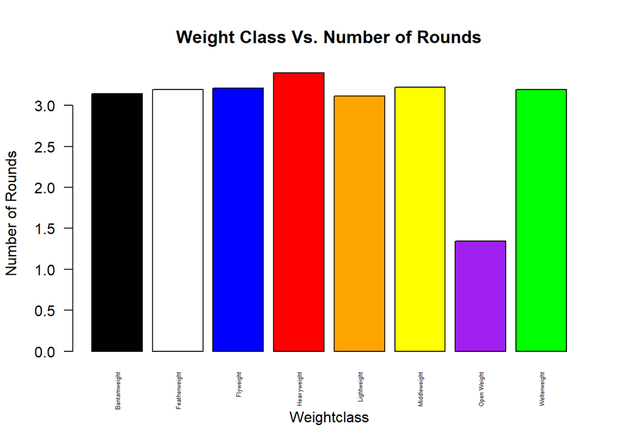

```r
#This graph plots the obvious but confirms the notion that the data shows the weight classes being divided by weight accurately. Of course, the heavier weight classes have higher average weights and the lower weight classes have lower average weights. As the weight classes go up, there are huge jumps in average weight.

#Number of Rounds
roundsplot<-tapply(ufc$no_of_rounds,ufc$weightclasses,mean, na.rm=TRUE)
roundsplot <- roundsplot[-1]
barplot(roundsplot, main="Weight Class Vs. Number of Rounds", xlab="Weightclass",  ylab="Number of Rounds", las=2, cex.names = .4, col=c("black", "white", "blue", "red", "orange", "yellow", "purple", "green"))
```

[output not shown]

```r
#This plot shows the average number of rounds in a fight segmented by weight class. There are 5 rounds in UFC fights, and the bar plot shows that most of the weight classes have similar averages, with heavyweights going the longest. It is interesting to note the outlier (Open Weight) being significantly less than the other weight classes.
```

####Exploring the data and Deleting Women/Catch

```r
#Step 1: Explore the Data and see what needs to be done
#names(ufc) #Looking at the various names, used to easily copy into GLM model
#str(ufc) #Data exploration
#summary(ufc) #Data exploration
#summary(bet$weight_class) #Checking to make sure that the new weightclass subdivide adds up correctly
#Need to make Winner Column 0 or 1: 1 Will be if Blue won (since Red is predicted winner). We will care more if there is an upset, since better odds.
ufc$Winner<-ifelse(ufc$Winner=="Blue",1,0)
#table(ufc$Winner) #Checking work to make sure the output is correct.
ufc$title_bout<-ifelse(ufc$title_bout=="True",1,0) #Makes a 1 if a title bout or 0 if not. Making binary since other-wise it is perfectly negatively correlated.
#table(ufc$title_bout) #Checking work to make sure the output is correct.

#Delete Catch weight, since this is not an official weight and thus is variable in weight for fights. Also, delete women's weight classes due to different fighting tactics.
ufc <- ufc[ufc$weight_class_Catch.Weight != 1, ]
ufc$weight_class_Catch.Weight<-NULL
ufc <- ufc[ufc$weight_class_Women.s.Bantamweight != 1, ]
ufc$weight_class_Women.s.Bantamweight <- NULL
ufc <- ufc[ufc$weight_class_Women.s.Featherweight != 1, ]
ufc$weight_class_Women.s.Featherweight <- NULL
ufc <- ufc[ufc$weight_class_Women.s.Flyweight != 1, ]
ufc$weight_class_Women.s.Flyweight <- NULL
ufc <- ufc[ufc$weight_class_Women.s.Strawweight != 1, ]
ufc$weight_class_Women.s.Strawweight <- NULL
```

####Finding The differences/Creating Better Variables

```r
#Step 2: Create Better Variables off the Data
#General Fighter Information: Height, Reach, Age and Weight
ufc$difference_height<-round(ufc$R_Height_cms-ufc$B_Height_cms,2)
ufc$difference_reach<-round(ufc$R_Reach_cms-ufc$B_Reach_cms,2)
ufc$difference_age<-as.numeric(ufc$R_age)-as.numeric(ufc$B_age)
ufc$difference_weight<-round(ufc$R_Weight_lbs-ufc$B_Weight_lbs,2)

#Fighter STR:
ufc$difference_avg_opp_SIG_STR_landed<-round(ufc$R_avg_opp_SIG_STR_landed-ufc$B_avg_opp_SIG_STR_landed,2)
ufc$difference_avg_SIG_STR_att<-round(ufc$R_avg_SIG_STR_att-ufc$B_avg_SIG_STR_att,2)
ufc$difference_avg_opp_TOTAL_STR_landed <- round(ufc$R_avg_opp_TOTAL_STR_landed-ufc$B_avg_opp_TOTAL_STR_landed,2)
ufc$difference_avg_opp_TOTAL_STR_att <- round(ufc$R_avg_opp_TOTAL_STR_att-ufc$B_avg_opp_TOTAL_STR_att,2)
ufc$difference_avg_TOTAL_STR_landed <- round(ufc$R_avg_TOTAL_STR_landed-ufc$B_avg_TOTAL_STR_landed,2)
ufc$difference_avg_TOTAL_STR_att <- round(ufc$R_avg_TOTAL_STR_att-ufc$B_avg_TOTAL_STR_att,2)
ufc$difference_avg_SIG_STR_pct<-round(ufc$R_avg_SIG_STR_pct-ufc$B_avg_SIG_STR_pct,2)

#Fighter Head:
ufc$difference_avg_opp_head_landed <- round(ufc$R_avg_opp_HEAD_landed-ufc$B_avg_opp_HEAD_landed,2)

#Fighter TD:
ufc$difference_avg_TD_att <- round(ufc$R_avg_TD_att-ufc$B_avg_TD_att,2)
ufc$difference_avg_TD_pct <- round(ufc$R_avg_TD_pct-ufc$B_avg_TD_pct,2)
ufc$difference_avg_opp_TD_pct <- round(ufc$R_avg_opp_TD_pct-ufc$B_avg_opp_TD_pct,2)

#Fighter Ground:
ufc$difference_avg_opp_GROUND_att <- round(ufc$R_avg_opp_GROUND_att-ufc$B_avg_opp_GROUND_att,2)
ufc$difference_avg_opp_GROUND_landed <- round(ufc$R_avg_opp_GROUND_landed-ufc$B_avg_opp_GROUND_landed,2)
ufc$difference_avg_GROUND_landed <- round(ufc$R_avg_GROUND_landed-ufc$B_avg_GROUND_landed,2)

#Fighter Leg:
ufc$difference_avg_opp_LEG_landed <- round(ufc$R_avg_opp_LEG_landed - ufc$B_avg_opp_LEG_landed,2)

#Fighter Body:
ufc$difference_avg_opp_BODY_landed <- round(ufc$R_avg_opp_BODY_landed - ufc$B_avg_opp_BODY_landed,2)

#Fighter Clinch:
ufc$difference_avg_CLINCH_landed <- round(ufc$R_avg_CLINCH_landed-ufc$B_avg_CLINCH_landed,2)
ufc$difference_avg_CLINCH_att <- round(ufc$R_avg_CLINCH_att-ufc$B_avg_CLINCH_att,2)

#Fighter Distance:
ufc$difference_avg_opp_DISTANCE_att <- round(ufc$R_avg_opp_DISTANCE_att-ufc$B_avg_opp_DISTANCE_att,2)

#Delete old variables, since the difference of fighters is important:
ufc$R_Height_cms<-NULL
ufc$B_Height_cms<-NULL
ufc$R_Reach_cms<-NULL
ufc$B_Reach_cms<-NULL
ufc$R_Weight_lbs<-NULL
ufc$B_Weight_lbs<-NULL
ufc$R_age<-NULL
ufc$B_age<-NULL
ufc$R_avg_opp_SIG_STR_landed <- NULL
ufc$B_avg_opp_SIG_STR_landed <- NULL
ufc$R_avg_SIG_STR_att <- NULL
ufc$B_avg_SIG_STR_att <- NULL
ufc$R_avg_opp_HEAD_landed <- NULL
ufc$B_avg_opp_HEAD_landed <- NULL
ufc$R_avg_TD_att <- NULL
ufc$B_avg_TD_att <- NULL
ufc$R_avg_opp_TOTAL_STR_landed<- NULL
ufc$B_avg_opp_TOTAL_STR_landed<- NULL
ufc$R_avg_opp_TOTAL_STR_att<- NULL
ufc$B_avg_opp_TOTAL_STR_att<- NULL
ufc$R_avg_opp_GROUND_att<- NULL
ufc$B_avg_opp_GROUND_att<- NULL
ufc$R_avg_opp_LEG_landed<- NULL
ufc$B_avg_opp_LEG_landed<- NULL
ufc$R_avg_opp_BODY_landed<- NULL
ufc$B_avg_opp_BODY_landed<- NULL
ufc$R_avg_opp_GROUND_landed<- NULL
ufc$B_avg_opp_GROUND_landed<- NULL
ufc$R_avg_TOTAL_STR_landed<- NULL
ufc$B_avg_TOTAL_STR_landed<- NULL
ufc$R_avg_TOTAL_STR_att<- NULL
ufc$B_avg_TOTAL_STR_att<- NULL
ufc$R_avg_CLINCH_landed <- NULL
ufc$B_avg_CLINCH_landed <- NULL
ufc$R_avg_CLINCH_att<- NULL
ufc$B_avg_CLINCH_att<- NULL
ufc$R_avg_TD_pct <- NULL
ufc$B_avg_TD_pct <- NULL
ufc$R_avg_opp_TD_pct <- NULL
ufc$B_avg_opp_TD_pct <- NULL
ufc$R_avg_SIG_STR_pct<- NULL
ufc$B_avg_SIG_STR_pct<- NULL
ufc$R_avg_GROUND_landed  <- NULL
ufc$B_avg_GROUND_landed  <- NULL

ufc$R_avg_opp_DISTANCE_att<- NULL
ufc$B_avg_opp_DISTANCE_att<- NULL

#The main aspect of this project that we had to deal with was cleaning the data and understanding what variables could be predictive of winning.  Because we are examining this data from the standpoint of a gambler, we needed to understand what specific traits of fights were most important, and as such, could be overlooked by others for a money-making opportunity.  What we first realized was the difficulty of tackling this problem when the data was formatted in a per fighter format.  Because each fight is a match-up, we found it fair to assume that looking for differences was going to yield us the best model.  By converting some of our variables from per fighter to differences between fighters, we were able to better understand which stood out.  The most logical pertinent pertained to physical details about the fighters rather than their stats.  Examples include: age, weight and height.  After we did a multitude of conversions we then researched how betting in UFC works.
```

####Data Cleaning With VIF STEP to Check For Collinearity and Delete Other ATT (Attempts)

```r
#Get rid of the rest of ATT:
ufc$B_avg_BODY_att<-NULL
ufc$B_avg_GROUND_att<-NULL
ufc$B_avg_HEAD_att<-NULL
ufc$B_avg_LEG_att<-NULL
ufc$B_avg_SUB_ATT<-NULL
ufc$B_avg_opp_BODY_att<-NULL
ufc$B_avg_opp_CLINCH_att<-NULL
ufc$B_avg_DISTANCE_att<-NULL
ufc$B_avg_opp_HEAD_att<-NULL
ufc$B_avg_opp_SIG_STR_att<-NULL
ufc$B_avg_opp_SUB_ATT<-NULL
ufc$B_avg_opp_TD_att<-NULL
ufc$R_avg_BODY_att<-NULL
ufc$R_avg_DISTANCE_att<-NULL
ufc$R_avg_GROUND_att<-NULL
ufc$R_avg_HEAD_att<-NULL
ufc$R_avg_LEG_att<-NULL
ufc$R_avg_SUB_ATT<-NULL
ufc$R_avg_opp_BODY_att <-NULL
ufc$R_avg_opp_CLINCH_att<-NULL
ufc$R_avg_opp_HEAD_att<-NULL
ufc$R_avg_opp_LEG_att<-NULL
ufc$R_avg_opp_SIG_STR_att<-NULL
ufc$R_avg_opp_SUB_ATT<-NULL
ufc$R_avg_opp_TD_att<-NULL

#Betting online is more important about the number of landed punches, leg, or other shots landed as prop-bets compared to att. Thus, since att and landed are two different variables, but correlated we deleted the rest of att (attempts). We Initially kept the differences calculated above since we felt that those metrics mattered the most out of all the attempts.

#We run VIF to check for collinearity. Did this in 3 frames first due to having issues if combined all at once. The summary of findings is at the bottom of the next chunk of code.
hypothesisvif1 <- data.frame(Winner = ufc$Winner,
      title_bout    = ufc$title_bout,
      no_of_rounds   = ufc$no_of_rounds,
      B_current_lose_streak   = ufc$B_current_lose_streak,
      B_current_win_streak = ufc$B_current_win_streak,
      B_avg_BODY_landed   = ufc$B_avg_BODY_landed,
      B_avg_DISTANCE_landed   = ufc$B_avg_DISTANCE_landed,
      B_avg_HEAD_landed    = ufc$B_avg_HEAD_landed,
      B_avg_KD        = ufc$B_avg_KD,
      B_avg_LEG_landed   = ufc$B_avg_LEG_landed,
      B_avg_PASS       = ufc$B_avg_PASS,
      B_avg_REV          = ufc$B_avg_REV,
      B_avg_SIG_STR_landed   = ufc$B_avg_SIG_STR_landed,
      B_avg_TD_landed          = ufc$B_avg_TD_landed,
      B_longest_win_streak     = ufc$B_longest_win_streak,
      B_losses                 = ufc$B_losses,
      B_avg_opp_CLINCH_landed  = ufc$B_avg_opp_CLINCH_landed,
      B_avg_opp_DISTANCE_landed   = ufc$B_avg_opp_DISTANCE_landed,
      B_avg_opp_KD     = ufc$B_avg_opp_KD
)

hypothesisvif2<-data.frame(B_avg_opp_LEG_att   = ufc$B_avg_opp_LEG_att,
      B_avg_opp_PASS  = ufc$B_avg_opp_PASS,
      B_avg_opp_REV    = ufc$B_avg_opp_REV,
      B_avg_opp_SIG_STR_pct  = ufc$B_avg_opp_SIG_STR_pct,
      B_avg_opp_TD_landed   = ufc$B_avg_opp_TD_landed,
      B_total_rounds_fought   = ufc$B_total_rounds_fought,
      B_total_time_fought.seconds.  = ufc$B_total_time_fought.seconds.,
      B_total_title_bouts   = ufc$B_total_title_bouts,
      B_win_by_Decision_Majority  = ufc$B_win_by_Decision_Majority,
      B_win_by_Decision_Split     = ufc$B_win_by_Decision_Split,
      B_win_by_Decision_Unanimous   = ufc$B_win_by_Decision_Unanimous,
      B_win_by_KO.TKO           = ufc$B_win_by_KO.TKO,
      B_win_by_Submission   = ufc$B_win_by_Submission,
      B_win_by_TKO_Doctor_Stoppage   = ufc$B_win_by_TKO_Doctor_Stoppage,
      B_wins                        = ufc$B_wins,
      R_current_lose_streak    = ufc$R_current_lose_streak,
      R_current_win_streak = ufc$R_current_win_streak,
      R_avg_BODY_landed    = ufc$R_avg_BODY_landed,
      R_avg_DISTANCE_landed    = ufc$R_avg_DISTANCE_landed,
      R_avg_HEAD_landed     = ufc$R_avg_HEAD_landed,
      R_avg_KD            = ufc$R_avg_KD,
      R_avg_LEG_landed    = ufc$R_avg_LEG_landed,
      R_avg_PASS          = ufc$R_avg_PASS,
      R_avg_REV            = ufc$R_avg_REV,
      R_avg_SIG_STR_landed   = ufc$R_avg_SIG_STR_landed,
      R_avg_TD_landed         = ufc$R_avg_TD_landed,
      R_longest_win_streak  = ufc$R_longest_win_streak,
      R_losses             = ufc$R_losses,
      R_avg_opp_CLINCH_landed   = ufc$R_avg_opp_CLINCH_landed,
      R_avg_opp_DISTANCE_landed  = ufc$R_avg_opp_DISTANCE_landed,
      R_avg_opp_KD        = ufc$R_avg_opp_KD,
      R_avg_opp_PASS     = ufc$R_avg_opp_PASS,
      R_avg_opp_REV    = ufc$R_avg_opp_REV,
      R_avg_opp_SIG_STR_pct   = ufc$R_avg_opp_SIG_STR_pct
     )

hypothesisvif3<- data.frame(R_avg_opp_TD_landed    = ufc$R_avg_opp_TD_landed,
      R_total_rounds_fought   = ufc$R_total_rounds_fought,
      R_total_time_fought.seconds. = ufc$R_total_time_fought.seconds.,
      R_total_title_bouts          = ufc$R_total_title_bouts,
      R_win_by_Decision_Majority  = ufc$R_win_by_Decision_Majority,
      R_win_by_Decision_Split      = ufc$R_win_by_Decision_Split,
      R_win_by_Decision_Unanimous   = ufc$R_win_by_Decision_Unanimous,
      R_win_by_KO.TKO             = ufc$R_win_by_KO.TKO,
      R_win_by_Submission         = ufc$R_win_by_Submission,
      R_win_by_TKO_Doctor_Stoppage  = ufc$R_win_by_TKO_Doctor_Stoppage,
      R_wins    = ufc$R_wins,
      weight_class_Bantamweight   = ufc$weight_class_Bantamweight,
      weight_class_Featherweight    = ufc$weight_class_Featherweight,
      weight_class_Flyweight       = ufc$weight_class_Flyweight,
      weight_class_Heavyweight     = ufc$weight_class_Heavyweight,
      weight_class_Light.Heavyweight  = ufc$weight_class_Light.Heavyweight,
      weight_class_Lightweight   = ufc$weight_class_Lightweight,
      weight_class_Middleweight  = ufc$weight_class_Middleweight,
      weight_class_Open.Weight   = ufc$weight_class_Open.Weight,
      weight_class_Welterweight  = ufc$weight_class_Welterweight,
      B_Stance_Open.Stance    = ufc$B_Stance_Open.Stance,
      B_Stance_Orthodox    = ufc$B_Stance_Orthodox,
      B_Stance_Sideways    = ufc$B_Stance_Sideways,
      B_Stance_Southpaw  = ufc$B_Stance_Southpaw,
      B_Stance_Switch     = ufc$B_Stance_Switch,
      R_Stance_Open.Stance  = ufc$R_Stance_Open.Stance,
      R_Stance_Orthodox      = ufc$R_Stance_Orthodox,
      R_Stance_Southpaw   = ufc$R_Stance_Southpaw,
      R_Stance_Switch       = ufc$R_Stance_Switch,
      difference_height   = ufc$difference_height,
      difference_reach   = ufc$difference_reach,
      difference_age   = ufc$difference_age,
      difference_weight  = ufc$difference_weight,
      difference_avg_opp_SIG_STR_landed=ufc$difference_avg_opp_SIG_STR_landed,
      difference_avg_SIG_STR_att    = ufc$difference_avg_SIG_STR_att,
      difference_avg_opp_TOTAL_STR_landed=ufc$difference_avg_opp_TOTAL_STR_landed,
      difference_avg_opp_TOTAL_STR_att=ufc$difference_avg_opp_TOTAL_STR_att,
      difference_avg_TOTAL_STR_landed=ufc$difference_avg_TOTAL_STR_landed,
      difference_avg_TOTAL_STR_att     = ufc$difference_avg_TOTAL_STR_att,
      difference_avg_SIG_STR_pct     = ufc$difference_avg_SIG_STR_pct,
      difference_avg_opp_head_landed  = ufc$difference_avg_opp_head_landed,
      difference_avg_TD_att        = ufc$difference_avg_TD_att,
      difference_avg_TD_pct   = ufc$difference_avg_TD_pct,
      difference_avg_opp_TD_pct    = ufc$difference_avg_opp_TD_pct,
      difference_avg_opp_GROUND_att   = ufc$difference_avg_opp_GROUND_att,
      difference_avg_opp_GROUND_landed= ufc$difference_avg_opp_GROUND_landed,
      difference_avg_GROUND_landed    = ufc$difference_avg_GROUND_landed,
      difference_avg_opp_LEG_landed    = ufc$difference_avg_opp_LEG_landed,
      difference_avg_opp_BODY_landed  = ufc$difference_avg_opp_BODY_landed,
      difference_avg_CLINCH_landed = ufc$difference_avg_CLINCH_landed,
      difference_avg_CLINCH_att=ufc$difference_avg_CLINCH_att,
      difference_avg_opp_DISTANCE_att=ufc$difference_avg_opp_DISTANCE_att
)

v1<-vifstep(as.matrix(hypothesisvif1[,c(2:19)]), th=10) #th is a threshold
v2<-vifstep(as.matrix(hypothesisvif2), th=10) #th is a threshold
v3<-vifstep(as.matrix(hypothesisvif3), th=10) #th is a threshold

#v1
#Issues From V1:
ufc$B_avg_BODY_landed<-NULL
ufc$B_avg_SIG_STR_landed<-NULL


#v2
ufc$R_avg_BODY_landed <-NULL
ufc$B_wins <-NULL
ufc$R_avg_SIG_STR_landed <-NULL
ufc$B_total_rounds_fought <-NULL
ufc$R_draw<-NULL
ufc$B_draw<-NULL

#v3
#weight_class_Bantamweight Kept since used to split weight classes
ufc$B_Stance_Open.Stance <-NULL
ufc$R_Stance_Open.Stance <-NULL
ufc$difference_avg_opp_SIG_STR_landed<-NULL
ufc$R_wins <-NULL
ufc$B_Stance_Orthodox<-NULL
ufc$difference_avg_opp_TOTAL_STR_att<-NULL
ufc$difference_avg_TOTAL_STR_att <-NULL
ufc$R_Stance_Orthodox <-NULL
ufc$difference_avg_CLINCH_att<-NULL
ufc$difference_avg_opp_GROUND_landed<-NULL
ufc$R_total_rounds_fought <-NULL
```

####Combined VIF STEP

```r
hypothesisv4 <- data.frame(Winner = ufc$Winner,
      R_avg_opp_TD_landed    = ufc$R_avg_opp_TD_landed,
      R_total_time_fought.seconds. = ufc$R_total_time_fought.seconds.,
      R_total_title_bouts          = ufc$R_total_title_bouts,
      R_win_by_Decision_Majority  = ufc$R_win_by_Decision_Majority,
      R_win_by_Decision_Split      = ufc$R_win_by_Decision_Split,
      R_win_by_Decision_Unanimous   = ufc$R_win_by_Decision_Unanimous,
      R_win_by_KO.TKO             = ufc$R_win_by_KO.TKO,
      R_win_by_Submission         = ufc$R_win_by_Submission,
      R_win_by_TKO_Doctor_Stoppage  = ufc$R_win_by_TKO_Doctor_Stoppage,
      weight_class_Featherweight    = ufc$weight_class_Featherweight,
      weight_class_Flyweight       = ufc$weight_class_Flyweight,
      weight_class_Heavyweight     = ufc$weight_class_Heavyweight,
      weight_class_Light.Heavyweight  = ufc$weight_class_Light.Heavyweight,
      weight_class_Lightweight   = ufc$weight_class_Lightweight,
      weight_class_Middleweight  = ufc$weight_class_Middleweight,
      weight_class_Open.Weight   = ufc$weight_class_Open.Weight,
      weight_class_Welterweight  = ufc$weight_class_Welterweight,
      B_Stance_Sideways    = ufc$B_Stance_Sideways,
      B_Stance_Southpaw  = ufc$B_Stance_Southpaw,
      B_Stance_Switch     = ufc$B_Stance_Switch,
      R_Stance_Southpaw   = ufc$R_Stance_Southpaw,
      R_Stance_Switch       = ufc$R_Stance_Switch,
      difference_height   = ufc$difference_height,
      difference_reach   = ufc$difference_reach,
      difference_age   = ufc$difference_age,
      difference_weight  = ufc$difference_weight,
      difference_avg_SIG_STR_att    = ufc$difference_avg_SIG_STR_att,
      difference_avg_opp_TOTAL_STR_landed=ufc$difference_avg_opp_TOTAL_STR_landed,
      difference_avg_TOTAL_STR_landed=ufc$difference_avg_TOTAL_STR_landed,
      difference_avg_SIG_STR_pct     = ufc$difference_avg_SIG_STR_pct,
      difference_avg_opp_head_landed  = ufc$difference_avg_opp_head_landed,
      difference_avg_TD_att        = ufc$difference_avg_TD_att,
      difference_avg_TD_pct   = ufc$difference_avg_TD_pct,
      difference_avg_opp_TD_pct    = ufc$difference_avg_opp_TD_pct,
      difference_avg_opp_GROUND_att   = ufc$difference_avg_opp_GROUND_att,
      difference_avg_GROUND_landed    = ufc$difference_avg_GROUND_landed,
      difference_avg_opp_LEG_landed    = ufc$difference_avg_opp_LEG_landed,
      difference_avg_opp_BODY_landed  = ufc$difference_avg_opp_BODY_landed,
      difference_avg_CLINCH_landed = ufc$difference_avg_CLINCH_landed,
      difference_avg_opp_DISTANCE_att=ufc$difference_avg_opp_DISTANCE_att,
      B_avg_opp_LEG_att   = ufc$B_avg_opp_LEG_att,
      B_avg_opp_PASS  = ufc$B_avg_opp_PASS,
      B_avg_opp_REV    = ufc$B_avg_opp_REV,
      B_avg_opp_SIG_STR_pct  = ufc$B_avg_opp_SIG_STR_pct,
      B_avg_opp_TD_landed   = ufc$B_avg_opp_TD_landed,
      B_total_time_fought.seconds.  = ufc$B_total_time_fought.seconds.,
      B_total_title_bouts   = ufc$B_total_title_bouts,
      B_win_by_Decision_Majority  = ufc$B_win_by_Decision_Majority,
      B_win_by_Decision_Split     = ufc$B_win_by_Decision_Split,
      B_win_by_Decision_Unanimous   = ufc$B_win_by_Decision_Unanimous,
      B_win_by_KO.TKO           = ufc$B_win_by_KO.TKO,
      B_win_by_Submission   = ufc$B_win_by_Submission,
      B_win_by_TKO_Doctor_Stoppage   = ufc$B_win_by_TKO_Doctor_Stoppage,
      R_current_lose_streak    = ufc$R_current_lose_streak,
      R_current_win_streak = ufc$R_current_win_streak,
      R_avg_DISTANCE_landed    = ufc$R_avg_DISTANCE_landed,
      R_avg_HEAD_landed     = ufc$R_avg_HEAD_landed,
      R_avg_KD            = ufc$R_avg_KD,
      R_avg_LEG_landed    = ufc$R_avg_LEG_landed,
      R_avg_PASS          = ufc$R_avg_PASS,
      R_avg_REV            = ufc$R_avg_REV,
      R_avg_TD_landed         = ufc$R_avg_TD_landed,
      R_longest_win_streak  = ufc$R_longest_win_streak,
      R_losses             = ufc$R_losses,
      R_avg_opp_CLINCH_landed   = ufc$R_avg_opp_CLINCH_landed,
      R_avg_opp_DISTANCE_landed  = ufc$R_avg_opp_DISTANCE_landed,
      R_avg_opp_KD        = ufc$R_avg_opp_KD,
      R_avg_opp_PASS     = ufc$R_avg_opp_PASS,
      R_avg_opp_REV    = ufc$R_avg_opp_REV,
      R_avg_opp_SIG_STR_pct   = ufc$R_avg_opp_SIG_STR_pct,
      title_bout    = ufc$title_bout,
      no_of_rounds   = ufc$no_of_rounds,
      B_current_lose_streak   = ufc$B_current_lose_streak,
      B_current_win_streak = ufc$B_current_win_streak,
      B_avg_DISTANCE_landed   = ufc$B_avg_DISTANCE_landed,
      B_avg_HEAD_landed    = ufc$B_avg_HEAD_landed,
      B_avg_KD        = ufc$B_avg_KD,
      B_avg_LEG_landed   = ufc$B_avg_LEG_landed,
      B_avg_PASS       = ufc$B_avg_PASS,
      B_avg_REV          = ufc$B_avg_REV,
      B_avg_TD_landed          = ufc$B_avg_TD_landed,
      B_longest_win_streak     = ufc$B_longest_win_streak,
      B_losses                 = ufc$B_losses,
      B_avg_opp_CLINCH_landed  = ufc$B_avg_opp_CLINCH_landed,
      B_avg_opp_DISTANCE_landed   = ufc$B_avg_opp_DISTANCE_landed,
      B_avg_opp_KD     = ufc$B_avg_opp_KD
)

v4<-vifstep(as.matrix(hypothesisv4[,c(2:ncol(hypothesisv4))]), th=7) #th is a threshold
#v4
#Ones Identified:
ufc$B_avg_opp_DISTANCE_landed<-NULL
ufc$B_avg_DISTANCE_landed<-NULL
ufc$R_avg_DISTANCE_landed<-NULL
ufc$difference_avg_opp_DISTANCE_att<-NULL
ufc$difference_avg_SIG_STR_att<-NULL

#However, to make sure our methodology was not overlooking collinerated variables, we decided to run VIF Step functions to test for collinearity.  We ran a few different versions, gradually trying to discover the problems in the new data set.  In our first VIF we eliminated: B_avg_BODY_landed and B_avg_SIG_STR_landed.  In our second, we eliminated r_avg_body_landed, B_wins, R_avg_SIG_STR_landed, B_total_rounds_fought, R_draw and B_draw.  In our third we eliminated another batch of 11 variables.  Finally, in our fourth we eliminated 5 more that showed signs of collinearity.
```

####Cleaning and Normalizing the Data

```r
#Remove all the Columns that just have 0's:
ufc<-ufc[, colSums(ufc != 0) > 0]
#Step 3(A): Randomize and Normalize the Data: Thus all algorithms will work
set.seed(123) #To make sure that the models are consistent
ufc_r<- ufc[sample(nrow(ufc)),] #selecting every row and column
ufc_mm<-as.data.frame(model.matrix(~ . -1, data=ufc_r)) #Gets rid of all factors
#summary(ufc_mm) #Commented-out for reading-ease
normalize <- function(x) {
  return((x - min(x)) / (max(x) - min(x)))
}
ufc_n<-as.data.frame(lapply(ufc_mm, normalize)) #Makes all the data between 0-1 for comparison

#After getting rid of the variables we needed to, we needed to proceed by cleaning and normalizing the data.  We set a seed to make models consistent, and then followed standard randomizing and normalizing procedure.
```

####Making New Data Set and Running GLM:

```r
#Testing Hypothesis with ALL Differences (Not Nulled out above):

glmhypothesis <- data.frame( Winner = ufc_n$Winner,
                         difference_height = ufc_n$difference_height,
                         difference_reach = ufc_n$difference_reach,
                         difference_age = ufc_n$difference_age,
                         difference_weight = ufc_n$difference_weight,
                         difference_avg_opp_TOTAL_STR_landed = ufc_n$difference_avg_opp_TOTAL_STR_landed,
                         difference_avg_TOTAL_STR_landed = ufc_n$difference_avg_TOTAL_STR_landed,
                         difference_avg_SIG_STR_pct = ufc_n$difference_avg_SIG_STR_pct,
                         difference_avg_opp_head_landed =ufc_n$difference_avg_opp_head_landed,
                         difference_avg_TD_att = ufc_n$difference_avg_TD_att,
                         difference_avg_TD_pct = ufc_n$difference_avg_TD_pct,
                         difference_avg_opp_TD_pct = ufc_n$difference_avg_opp_TD_pct,
                         difference_avg_opp_GROUND_att = ufc_n$difference_avg_opp_GROUND_att,
                         difference_avg_GROUND_landed = ufc_n$difference_avg_GROUND_landed,
                         difference_avg_opp_LEG_landed = ufc_n$difference_avg_opp_LEG_landed,
                         difference_avg_opp_BODY_landed = ufc_n$difference_avg_opp_BODY_landed,
                         difference_avg_CLINCH_landed = ufc_n$difference_avg_CLINCH_landed
                       )

#str(glmhypothesis)

model1<-glm(Winner~., data=glmhypothesis, family = "binomial")
#summary(model1)

#AIC 4117

#Testing Hypothesis with no att:

glmhypothesis2 <- data.frame( Winner = ufc_n$Winner,
                         difference_height = ufc_n$difference_height,
                         difference_reach = ufc_n$difference_reach,
                         difference_age = ufc_n$difference_age,
                         difference_weight = ufc_n$difference_weight,
                         difference_avg_opp_TOTAL_STR_landed = ufc_n$difference_avg_opp_TOTAL_STR_landed,
                         difference_avg_TOTAL_STR_landed = ufc_n$difference_avg_TOTAL_STR_landed,
                         difference_avg_SIG_STR_pct = ufc_n$difference_avg_SIG_STR_pct,
                         difference_avg_opp_head_landed =ufc_n$difference_avg_opp_head_landed,
                         difference_avg_TD_pct = ufc_n$difference_avg_TD_pct,
                         difference_avg_opp_TD_pct = ufc_n$difference_avg_opp_TD_pct,
                         difference_avg_GROUND_landed = ufc_n$difference_avg_GROUND_landed,
                         difference_avg_opp_LEG_landed = ufc_n$difference_avg_opp_LEG_landed,
                         difference_avg_opp_BODY_landed = ufc_n$difference_avg_opp_BODY_landed,
                         difference_avg_CLINCH_landed = ufc_n$difference_avg_CLINCH_landed
                       )

model2<-glm(Winner~., data=glmhypothesis2, family = "binomial")
#summary(model2)

#AIC 4133

#Testing Hypothesis with no att - Narrowed Down:

glmhypothesis3 <- data.frame( Winner = ufc_n$Winner,
                         difference_height = ufc_n$difference_height,
                         difference_reach = ufc_n$difference_reach,
                         difference_age = ufc_n$difference_age,
                         difference_avg_opp_head_landed =ufc_n$difference_avg_opp_head_landed,
                         difference_avg_opp_TD_pct = ufc_n$difference_avg_opp_TD_pct,
                         difference_avg_opp_LEG_landed = ufc_n$difference_avg_opp_LEG_landed,
                         difference_avg_opp_BODY_landed = ufc_n$difference_avg_opp_BODY_landed,
                         difference_avg_CLINCH_landed = ufc_n$difference_avg_CLINCH_landed

                       )

model3<-glm(Winner~., data=glmhypothesis3, family = "binomial")
#summary(model3)

# AIC 4137

#We first tried our own-hand at finding the optimal variables for data-selection and we minimized AIC at 4117 with hypothesis 1. Next we will see what the computer can do.
```

#### Running GLM Model to reduce Variables

```r
model<-lm(Winner~., data=ufc_n)
#summary(model)

#computerglm<-olsmodel<-ols_step_forward_aic(model, progress = FALSE)

#plot(computerglm)

#This shows us the most important variables as they each decrease the AIC. We will pull the top 10 to have the largest impact.

#Use the Top 10 of AIC from  OLS Model
#And Top 7 that our team thought most important from above

glmmodel<-glm(Winner~ difference_age + R_avg_opp_DISTANCE_landed+ B_avg_HEAD_landed + R_losses +difference_avg_TD_att + R_avg_opp_SIG_STR_pct+ R_total_title_bouts + difference_avg_opp_TOTAL_STR_landed+ R_win_by_Decision_Split + title_bout +  difference_reach+difference_height+difference_avg_opp_TD_pct + difference_avg_opp_head_landed + difference_avg_CLINCH_landed+ difference_weight+difference_avg_GROUND_landed, data=ufc_n, family="binomial" )
#summary(glmmodel)

#AIC of 3943

#The computer was able to beat us with an AIC of 3943. Next we will cheat for correlation with this data set.
```

####Making the final dataset to run through models

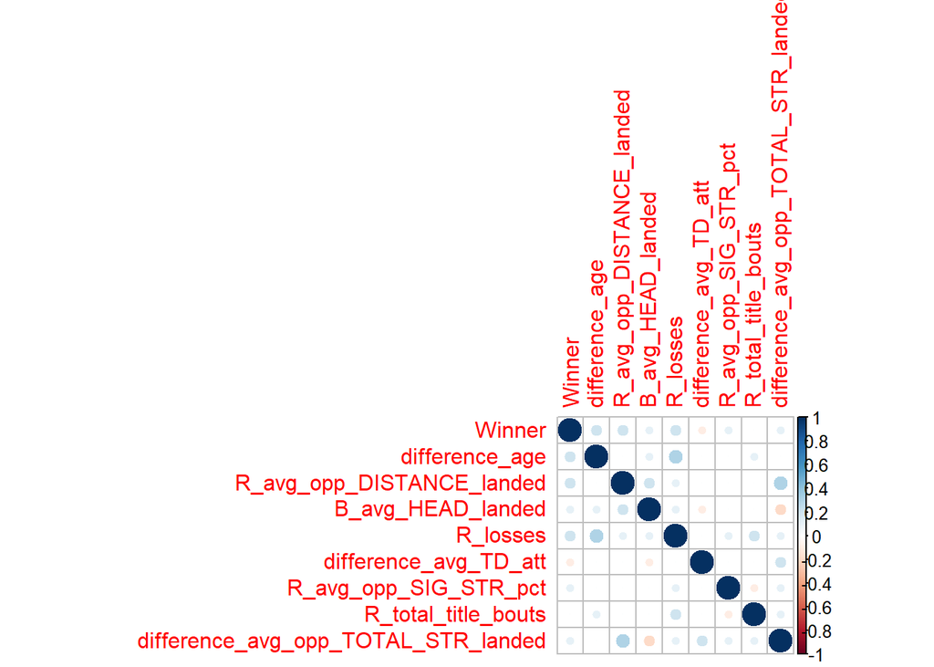

```r
data_final1 <- data.frame( Winner = ufc_n$Winner,
                         difference_age = ufc_n$difference_age,
                         R_avg_opp_DISTANCE_landed=ufc_n$R_avg_opp_DISTANCE_landed,
                         B_avg_HEAD_landed=ufc_n$B_avg_HEAD_landed,
                         R_losses=ufc_n$R_losses,
                         difference_avg_TD_att = ufc_n$difference_avg_TD_att,
                         R_avg_opp_SIG_STR_pct=ufc_n$R_avg_opp_SIG_STR_pct,
                         R_total_title_bouts=ufc_n$R_total_title_bouts,
                         difference_avg_opp_TOTAL_STR_landed=ufc_n$difference_avg_opp_TOTAL_STR_landed,
                         R_win_by_Decision_Split=ufc_n$R_win_by_Decision_Split,
                         title_bout=ufc_n$title_bout,
                         no_of_rounds=ufc_n$no_of_rounds,
                         difference_height = ufc_n$difference_height,
                         difference_reach = ufc_n$difference_reach,
                         difference_weight=ufc_n$difference_weight,
                         difference_avg_GROUND_landed = ufc_n$difference_avg_GROUND_landed,
                         difference_avg_opp_TD_pct=ufc_n$difference_avg_opp_TD_pct,
                         difference_avg_opp_head_landed=ufc_n$difference_avg_opp_head_landed,
                         difference_avg_CLINCH_landed=ufc_n$difference_avg_CLINCH_landed,
                         weight_class_Flyweight=ufc_n$weight_class_Flyweight,
                         weight_class_Bantamweight=ufc_n$weight_class_Bantamweight,
                         weight_class_Featherweight=ufc_n$weight_class_Featherweight,
                        weight_class_Lightweight=ufc_n$weight_class_Lightweight,
                        weight_class_Welterweight=ufc_n$weight_class_Welterweight,
                        weight_class_Middleweight=ufc_n$weight_class_Middleweight,                                         weight_class_Light.Heavyweight=ufc_n$weight_class_Light.Heavyweight,
                        weight_class_Heavyweight=ufc_n$weight_class_Heavyweight
                       )

data_final_cor1 <- round(cor((data_final1[,1:9])),1)
data_final_cor2 <- round(cor((data_final1[,10:18])),1)
corrplot(data_final_cor1)
```

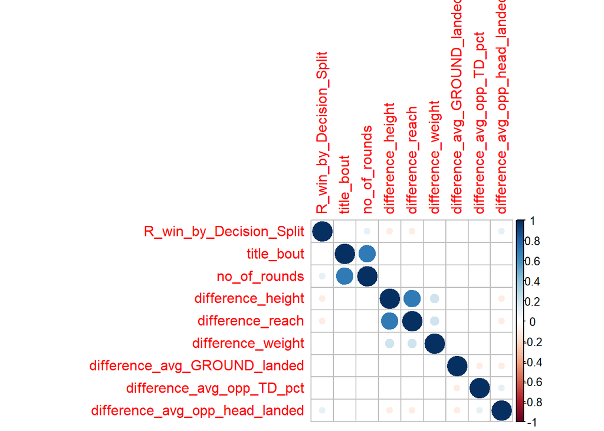

```r
corrplot(data_final_cor2)
```

```r
#Correlation seems to show some issues. There is some correlation, between number of rounds vs title bout and height vs reach. We took out title bouts since that is partially already captured by R_total_title_bouts. We took out difference_reach since we felt that height was more important due fighting styles and weight also having influence coming from height.

glmmodel2<-glm(Winner~ difference_age + R_avg_opp_DISTANCE_landed+ B_avg_HEAD_landed + R_losses +difference_avg_TD_att + R_avg_opp_SIG_STR_pct+ R_total_title_bouts + difference_avg_opp_TOTAL_STR_landed+ R_win_by_Decision_Split+no_of_rounds+difference_height+difference_avg_opp_TD_pct + difference_avg_opp_head_landed + difference_avg_CLINCH_landed+ difference_weight+difference_avg_GROUND_landed, data=ufc_n, family="binomial" )
#summary(glmmodel2)

#AIC 3970 With No correlation issues- This will become final data set.

data_final_final <- data.frame( Winner = ufc_n$Winner,
                         difference_age = ufc_n$difference_age,
                         R_avg_opp_DISTANCE_landed=ufc_n$R_avg_opp_DISTANCE_landed,
                         B_avg_HEAD_landed=ufc_n$B_avg_HEAD_landed,
                         R_losses=ufc_n$R_losses,
                         difference_avg_TD_att = ufc_n$difference_avg_TD_att,
                         R_avg_opp_SIG_STR_pct=ufc_n$R_avg_opp_SIG_STR_pct,
                         R_total_title_bouts=ufc_n$R_total_title_bouts,
                         difference_avg_opp_TOTAL_STR_landed=ufc_n$difference_avg_opp_TOTAL_STR_landed,
                         R_win_by_Decision_Split=ufc_n$R_win_by_Decision_Split,
                         no_of_rounds=ufc_n$no_of_rounds,
                         difference_height = ufc_n$difference_height,
                         difference_weight=ufc_n$difference_weight,
                         difference_avg_GROUND_landed = ufc_n$difference_avg_GROUND_landed,
                         difference_avg_opp_TD_pct=ufc_n$difference_avg_opp_TD_pct,
                         difference_avg_opp_head_landed=ufc_n$difference_avg_opp_head_landed,
                         difference_avg_CLINCH_landed=ufc_n$difference_avg_CLINCH_landed,
                         weight_class_Flyweight=ufc_n$weight_class_Flyweight,
                         weight_class_Bantamweight=ufc_n$weight_class_Bantamweight,
                         weight_class_Featherweight=ufc_n$weight_class_Featherweight,
                        weight_class_Lightweight=ufc_n$weight_class_Lightweight,
                        weight_class_Welterweight=ufc_n$weight_class_Welterweight,
                        weight_class_Middleweight=ufc_n$weight_class_Middleweight,                                weight_class_Light.Heavyweight=ufc_n$weight_class_Light.Heavyweight,
                        weight_class_Heavyweight=ufc_n$weight_class_Heavyweight
                       )

ufc_n<-data_final_final #This command sets the ufc_n to only include the variables that throrugh computer and self-selection we believe are the most relevant to betting on UFC fights.

#summary(ufc_n)

#In summary of the three above code chunks: We ran numerous GLM models with the goal of minimizing our AIC to try and get a dataset that had a sufficient number of predictive variables.  After running a few different iterations seeing how utilizing only differences would pan out, we then used an OLS to do a final refinement.  After using the best variables from the OLS, we got a GLM with our lowest AIC of around 3950. We found most significant variables (after correlation deletion of two) to be differences in age, R_avg_opp_distance_landed, B_avg_head_landed, R_losses, differences_age_TD_att, R_avg_opp_SIG_STR_pct, R_total_title_bouts, R_win_by_decision_split and difference_avg_opp_TD_pct.  This model resulted in the creation of our final data set to be used in subsequent models.
```

#####Dividing the Normalized Data into Various Classes

```r
#Creating different weight classes for guys
ufc_under_165<- filter(ufc_n, weight_class_Flyweight==1 | weight_class_Bantamweight==1 | weight_class_Featherweight==1| weight_class_Lightweight==1 )
ufc_over_165<- filter(ufc_n, weight_class_Light.Heavyweight==1 | weight_class_Heavyweight==1| weight_class_Middleweight==1|weight_class_Welterweight==1)
#summary(ufc_under_165) #Data exploration
#str(ufc_under_165) #Data exploration
#summary(ufc_over_165) #Data exploration
#str(ufc_over_165) #Data exploration
#Removing Columns that only have 0's (blanks):
ufc_under_165<-ufc_under_165[, colSums(ufc_under_165 != 0) > 0]
ufc_over_165<-ufc_over_165[, colSums(ufc_over_165 != 0) > 0]

#Based on the aforementioned information about differences by weight class, we thought that we would optimize our models by running them on different weight classes.   This is because based on research we have found that different variables become more or less important based on these distinctions.
```

####Train and Test Datasets

```r
#Looking at str to find the number of rows and where the Y Variable is located. Using 20% for test data
#str(ufc_under_165) #1430 data rows: 20%=286 & column 1= Y Variable
#str(ufc_over_165) #1902 data rows: 20%=381 & column 1= Y Variable
#str(ufc_n) #3367 rows: 20%=674  and column 1= Y variable
#KNN=Need Labels Seperated out
ufc_train_KNN<-ufc_n[675:nrow(ufc_n),-1]
ufc_train_labels_KNN<-ufc_n[675:nrow(ufc_n),1]
ufc_test_KNN<-ufc_n[1:674,-1]
ufc_test_labels_KNN<-ufc_n[1:674,1]
#ANN and SVM Keep Labels in the Data
ufc_train<-ufc_n[675:nrow(ufc_n),]
ufc_test<-ufc_n[1:674,]
#KNN=Need Labels Seperated out for Under 165
ufc_under_165_train_KNN<-ufc_under_165[287:nrow(ufc_under_165),-1]
ufc_under_165_train_labels_KNN<-ufc_under_165[287:nrow(ufc_under_165),1]
ufc_under_165_test_KNN<-ufc_under_165[1:286,-1]
ufc_under_165_test_labels_KNN<-ufc_under_165[1:286,1]
#ANN and SVM Keep Labels in the Data for Under 165
ufc_under_165_train<-ufc_under_165[287:nrow(ufc_under_165),]
ufc_under_165_test<-ufc_under_165[1:286,]
#KNN=Need Labels Seperated out for over 165
ufc_over_165_train_KNN<-ufc_over_165[382:nrow(ufc_over_165),-1]
ufc_over_165_train_labels_KNN<-ufc_over_165[382:nrow(ufc_over_165),1]
ufc_over_165_test_KNN<-ufc_over_165[1:381,-1]
ufc_over_165_test_labels_KNN<-ufc_over_165[1:381,1]
#ANN and SVM Keep Labels in the Data for over 165
ufc_over_165_train<-ufc_over_165[382:nrow(ufc_over_165),]
ufc_over_165_test<-ufc_over_165[1:381,]
#We then of course had to create train and test data sets for the models we wanted to make to see how accurate they were.  We used an approximately 80%-20% breakdown for the train and test respectively.  We created these different train and test datasets for KNN (removed the data's y column and placed into labels) and GLM/ANN/SVM/Tree.

#For the models we highlighted the accuracry percentages below each confusionMatrix. We attempted to beat the No Information rate in every model, since that is the baseline. While we hid the summary and str lines, we felt the confusionMatrices were important enough to show for each (this makes the file 72 pages long while printing, so to reduce to about 20 hide the matrices)
```

####First Model: GLM Model

```r
#All:
GLMall<-glm(Winner~ difference_age + R_avg_opp_DISTANCE_landed+ B_avg_HEAD_landed + R_losses +difference_avg_TD_att + R_avg_opp_SIG_STR_pct+ R_total_title_bouts + difference_avg_opp_TOTAL_STR_landed+ R_win_by_Decision_Split+difference_height+difference_avg_opp_TD_pct + difference_avg_opp_head_landed + difference_avg_CLINCH_landed+ difference_weight+difference_avg_GROUND_landed, data=ufc_train, family="binomial" )

#Train_All
prediction_all_train<-ifelse(predict(GLMall, newdata=ufc_train, type= "response") >= 0.47, 1,0)
confusionMatrix(as.factor(prediction_all_train),as.factor(ufc_train$Winner))
```

```
## Confusion Matrix and Statistics
##
##           Reference
## Prediction    0    1
##          0 1591  609
##          1  205  288
##
##                Accuracy : 0.6977
##                  95% CI : (0.68, 0.715)
##     No Information Rate : 0.6669
##     P-Value [Acc > NIR] : 0.000339
##
##                   Kappa : 0.2332
##
##  Mcnemar's Test P-Value : < 2.2e-16
##
##             Sensitivity : 0.8859
##             Specificity : 0.3211
##          Pos Pred Value : 0.7232
##          Neg Pred Value : 0.5842
##              Prevalence : 0.6669
##          Detection Rate : 0.5908
##    Detection Prevalence : 0.8169
##       Balanced Accuracy : 0.6035
##
##        'Positive' Class : 0
##
```

```r
# Accuracy: 0.6977

#Test_All
prediction_all_test<-ifelse(predict(GLMall, newdata=ufc_test, type= "response") >= 0.49, 1,0)
confusionMatrix(as.factor(prediction_all_test),as.factor(ufc_test$Winner))
```

```
## Confusion Matrix and Statistics
##
##           Reference
## Prediction   0   1
##          0 395 163
##          1  53  63
##
##                Accuracy : 0.6795
##                  95% CI : (0.6428, 0.7146)
##     No Information Rate : 0.6647
##     P-Value [Acc > NIR] : 0.2197
##
##                   Kappa : 0.1825
##
##  Mcnemar's Test P-Value : 1.202e-13
##
##             Sensitivity : 0.8817
##             Specificity : 0.2788
##          Pos Pred Value : 0.7079
##          Neg Pred Value : 0.5431
##              Prevalence : 0.6647
##          Detection Rate : 0.5861
##    Detection Prevalence : 0.8279
##       Balanced Accuracy : 0.5802
##
##        'Positive' Class : 0
##
```